# DA5020 – Assignment 10

```r
library(openintro)
library(GGally)
library(tidyverse)
library(ggplot2)
```

#### Question 1.1 - (20 pts) Load the data and build a full correlation matrix ,i.e.,a matrix that shows the correlations between all variables. Do you detect any multi-collinearity that would affect the construction of a multiple regression model? Comment on the distribution of each field.

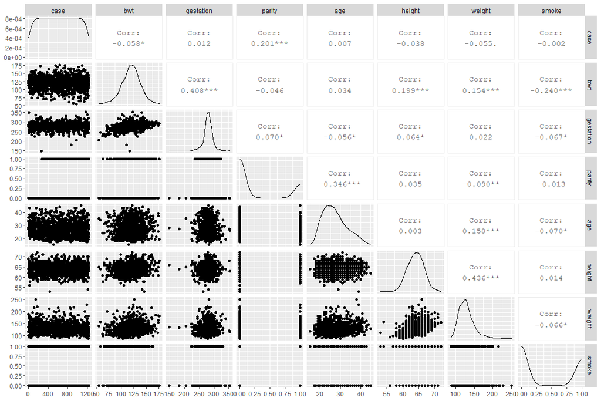

```r
ggpairs(babies)
```

#### Question 1.2 - (20pts) Build a full multiple regression model that predicts the birth weight i.e bwt. Comment on the model: R-squared, Standard Error, F-Statistic, p-values of coefficients.

```r
bwt_model <- lm(bwt ~ gestation + parity  + age + height + weight + smoke,
                data = babies)

summary(bwt_model)
```

```
Call:
lm(formula = bwt ~ gestation + parity + age + height + weight +
    smoke, data = babies)

Residuals:
    Min      1Q  Median      3Q     Max
-57.613 -10.189  -0.135   9.683  51.713

Coefficients:
             Estimate Std. Error t value Pr(>|t|)
(Intercept) -80.41085   14.34657  -5.605 2.60e-08 ***
gestation     0.44398    0.02910  15.258  < 2e-16 ***
parity       -3.32720    1.12895  -2.947  0.00327 **
age          -0.00895    0.08582  -0.104  0.91696
height        1.15402    0.20502   5.629 2.27e-08 ***
weight        0.05017    0.02524   1.987  0.04711 *
smoke        -8.40073    0.95382  -8.807  < 2e-16 ***
---
Signif. codes:  0 ‘***’ 0.001 ‘**’ 0.01 ‘*’ 0.05 ‘.’ 0.1 ‘ ’ 1

Residual standard error: 15.83 on 1167 degrees of freedom
  (62 observations deleted due to missingness)
Multiple R-squared:  0.258, Adjusted R-squared:  0.2541
F-statistic: 67.61 on 6 and 1167 DF,  p-value: < 2.2e-16
```

#### Question 1.3 - (15 pts) Derive the prediction equation and use the following values to predict birth weight: case = 12367, gestation = 290, parity = 0, age = 24, height = 67, weight = 135, smoke=0

```r
## coefficients and intercept to calculate bwt
bwt_model$coefficients
```

```
  (Intercept)     gestation        parity           age        height        weight         smoke
-80.410853396   0.443978339  -3.327199613  -0.008950305   1.154020364   0.050165027  -8.400733484
```

```r
## write function using coefficients
predict_fn <- function(gestation, parity, age,
                       height, weight, smoke) {
  bwt <-
    (0.443978339*gestation) + (-3.327199613*parity) + (-0.008950305*age) +
    (1.154020364*height) + (0.050165027*weight) + (-8.400733484*smoke) +
    (-80.410853396)
  return(bwt)
}
predict_fn(gestation = 290, parity = 0, age = 24,
           height = 67, weight = 135, smoke = 0)
```

```
[1] 132.2197
```

```r
## or use the built in function
bwt_predict <-
    predict(bwt_model, data.frame(
  case      = 12367,
  gestation = 290,
  parity    = 0,
  age       = 24,
  height    = 67,
  weight    = 135,
  smoke     = 0
))
```

With the given input parameters, the predicted birthweight is 132.

#### Question 1.4 - (10 pts) Define the 95% prediction interval for the prediction in (3) — use the standard error from the model output

```r
c(bwt_predict - 1.96*15.83, bwt_predict + 1.96*15.83)
```

```
       1        1
101.1929 163.2465
```

```r
paste0("range = ", (bwt_predict + 1.96*15.83) - (bwt_predict - 1.96*15.83))
```

```
[1] "range = 62.0536"
```

The predicted bwt is in the range of 101.1929 to 163.2465 with a confidence level of 95%.

#### Question 1.5 - (20Pts) Build a multiple regression model in which all coefficients are significant — use stepwise backward elimination based on coefficients with the p-value > 0.05.

```r
## the factor with the largest p-value was age
## exclude age
bwt_model_2 <- lm(bwt ~ gestation + parity + height + weight + smoke,
                data = babies)

summary(bwt_model_2)
```

```
Call:
lm(formula = bwt ~ gestation + parity + height + weight + smoke,
    data = babies)

Residuals:
    Min      1Q  Median      3Q     Max
-57.713 -10.151  -0.156   9.672  51.597

Coefficients:
             Estimate Std. Error t value Pr(>|t|)
(Intercept) -80.63568   14.03671  -5.745 1.17e-08 ***
gestation     0.44400    0.02906  15.280  < 2e-16 ***
parity       -3.29166    1.06231  -3.099  0.00199 **
height        1.15378    0.20461   5.639 2.14e-08 ***
weight        0.04999    0.02501   1.999  0.04589 *
smoke        -8.38341    0.95013  -8.823  < 2e-16 ***
---
Signif. codes:  0 ‘***’ 0.001 ‘**’ 0.01 ‘*’ 0.05 ‘.’ 0.1 ‘ ’ 1

Residual standard error: 15.82 on 1169 degrees of freedom
  (61 observations deleted due to missingness)
Multiple R-squared:  0.2579,    Adjusted R-squared:  0.2547
F-statistic: 81.26 on 5 and 1169 DF,  p-value: < 2.2e-16
```

Excluding age does not improve the model significantly. The R-squared and standard error are the same as before. All remaining p-values are statistically significant.

#### Question 1.6 - (15 pts) Predict birth weight using the following values:

case = 12367, gestation = 290, parity = 0, age = 24, height = 67, weight = 135, smoke=0 – don’t use the value that are not meaningful. Compare that prediction to the one obtained in (3). Comment on the difference and the utility of these models.

```r
## predict weight
bwt_predict_2 <-
  predict(bwt_model_2, data.frame(
  gestation = 290,
  parity    = 0,
  height    = 67,
  weight    = 135,
  smoke     = 0
))

bwt_predict_2
```

```
       1
132.1771
```

```r
## calculate 95% CI
c(bwt_predict_2 - 1.96*15.82, bwt_predict_2 + 1.96*15.82)
```

```
       1        1
101.1699 163.1843
```

```r
paste0("range = ", (bwt_predict_2 + 1.96*15.82) - (bwt_predict_2 - 1.96*15.82))
```

```
[1] "range = 62.0144"
```

Both models are equally useful (or useless) as the R-squared and standard error are the same, as well as the predicted bwt and 95% CI.

#### Question 2.1 - (10 pts) Load the Body Mass Index (BMI) dataset “500_Person_Gender_Height_Weight_Index.csv” that contains 500 observations on the BMI based on individuals height, weight and gender. Build a full correlation matrix; comment on the correlations and the distribution.

```r
bmi <- read_csv("500_Person_Gender_Height_Weight_Index.csv")
```

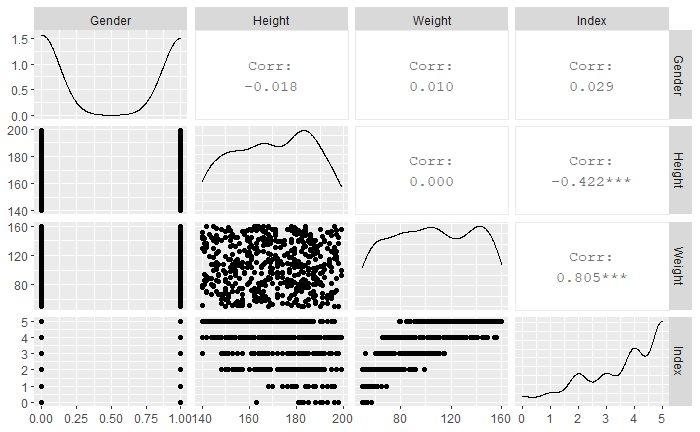

```r
bmi %>% mutate(Gender = if_else(Gender == "Male", 1, 0)) %>% ggpairs()
```

The strongest correlation to note is between weight and index (0.805), however, neither index, nor any other factor show a normal distribution. There is also a statistically significant (but weak) correlation between height and index.

#### Question 2.2 - (10 pts) Does any field in the data need to be transformed or encoded? If yes, perform the required steps.

As shown in Q2.1, the gender data is a binary factor and can be represented as “1” and “0”

```r
bmi %>% distinct(Gender)
```

| Gender |
| --- |
| Male |
| Female |

```r
bmi <-
  bmi %>%
  mutate(Gender = if_else(Gender == "Male", 1, 0))
bmi %>%
  head()
```

| Gender | Height | Weight | Index |
| --- | --- | --- | --- |
| 1 | 174 | 96 | 4 |
| 1 | 189 | 87 | 2 |
| 0 | 185 | 110 | 4 |
| 0 | 195 | 104 | 3 |
| 1 | 149 | 61 | 3 |
| 1 | 189 | 104 | 3 |

#### Question 2.3 - (20pts) Build a full multiple regression model, in which all coefficients are significant, that predicts the body mass index i.e Index. Comment on the model: R-squared, Standard Error, F-Statistic, p-values of coefficients.

```r
bmi_model <- lm(Index ~ Gender + Height + Weight, bmi)
summary(bmi_model)
```

```
Call:
lm(formula = Index ~ Gender + Height + Weight, data = bmi)

Residuals:
    Min      1Q  Median      3Q     Max
-2.3228 -0.3861  0.0654  0.3917  1.0970

Coefficients:
              Estimate Std. Error t value Pr(>|t|)
(Intercept)  6.1002043  0.2787214  21.886   <2e-16 ***
Gender       0.0369855  0.0507158   0.729    0.466
Height      -0.0349487  0.0015497 -22.552   <2e-16 ***
Weight       0.0336697  0.0007836  42.969   <2e-16 ***
---
Signif. codes:  0 ‘***’ 0.001 ‘**’ 0.01 ‘*’ 0.05 ‘.’ 0.1 ‘ ’ 1

Residual standard error: 0.5668 on 496 degrees of freedom
Multiple R-squared:  0.8261,    Adjusted R-squared:  0.825
F-statistic: 785.4 on 3 and 496 DF,  p-value: < 2.2e-16
```

```r
bmi_model <- lm(Index ~ Height + Weight, bmi)
summary(bmi_model)
```

```
Call:
lm(formula = Index ~ Height + Weight, data = bmi)

Residuals:
     Min       1Q   Median       3Q      Max
-2.34074 -0.38219  0.06156  0.39778  1.11542

Coefficients:
              Estimate Std. Error t value Pr(>|t|)
(Intercept)  6.1211460  0.2771076   22.09   <2e-16 ***
Height      -0.0349686  0.0015487  -22.58   <2e-16 ***
Weight       0.0336751  0.0007832   43.00   <2e-16 ***
---
Signif. codes:  0 ‘***’ 0.001 ‘**’ 0.01 ‘*’ 0.05 ‘.’ 0.1 ‘ ’ 1

Residual standard error: 0.5665 on 497 degrees of freedom
Multiple R-squared:  0.8259,    Adjusted R-squared:  0.8252
F-statistic:  1179 on 2 and 497 DF,  p-value: < 2.2e-16
```

Removing Gender has not degraded the quality of the model.

#### Question 2.4 - (10 pts) Create a data frame with at least 5 observations (i.e. comprising the gender, weight and height) that you will used to test your model. Predict the body mass index i.e Index for the sample data and define the 95% prediction interval. Comment on the predictions. Note: you can use the predict function to answer this question.

```r
set.seed(2020)                          ## reproducible

body_tbl <- tibble(
  "Gender" = c(0, 1, 0, 0, 1),          ## 1 == male, 0 == female
  "Weight" = round(runif(5, 80, 160)),  ## random weights
  "Height" = round(runif(5, 140, 200)), ## random heights
)
body_tbl <-
  body_tbl %>%
  mutate(Index = round(predict(bmi_model, body_tbl)),     ## predict index
         CI    = paste0(                                  ## calculate CI
           round(Index - 1.96*0.5665, 2), ", ",
           round(Index + 1.96*0.5665, 2)),
         Gender = if_else(Gender == 1, "Male", "Female")) ## fix gender
body_tbl
```

| Gender | Weight | Height | Index | CI |
| --- | --- | --- | --- | --- |
| Female | 132 | 144 | 6 | 4.89, 7.11 |
| Male | 112 | 148 | 5 | 3.89, 6.11 |
| Female | 129 | 164 | 5 | 3.89, 6.11 |
| Female | 118 | 140 | 5 | 3.89, 6.11 |
| Male | 91 | 177 | 3 | 1.89, 4.11 |

Where are the predicted indices within the context of the known ones?

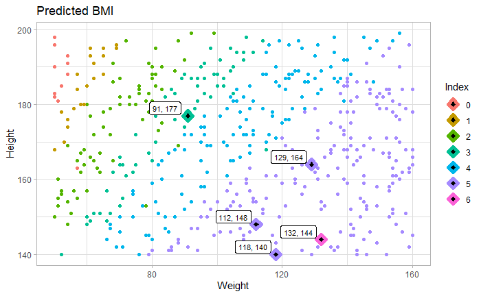

```r
bmi %>%
  ggplot(aes(
    x = Weight,
    y = Height)) +
  geom_point(aes(color = as.factor(Index))) +
  labs(title = "Predicted BMI") +
  guides(color = guide_legend(title = "Index")) +
  theme_light() +
  geom_point(
    data = body_tbl,
    aes(color = as.factor(Index),
        x     = Weight,
        y     = Height),
    pch    = 23,
    fill   = "black",
    size   = 2,
    stroke = 3) +
  annotate(geom  = "label",
           x     = body_tbl$Weight - 7,
           y     = body_tbl$Height + 2,
           label = paste0(body_tbl$Weight, ", ", body_tbl$Height),
           fill  = "white",
           size  = 3)
```

The predicted BMI appear to be in the expected positions based on weight and height. Notably, a prediction using weight and height of 132 and 144 respectively, produces a BMI which is out of the range of the training data. This makes sense because weights of approximately 130 in the training data have heights which are > 150, so a weight of 132 on an individual with height 144 would result in a higher BMI.